# Kidwai_Anam_Final project_Updated

03-701 Final project

1. HW2-Q4

a. Use pandas to read the data from calcium_curves.xlsx, print the loaded data. (Note: the output should have columns “Intensity Mean”, “Unit”, “Category”…)

```python
import pandas as pd
# Read the data from calcium_curves.xlsx
data = pd.read_excel('calcium_curves.xlsx')# Print the loaded data
print(data)
# Print the columns of the loaded data
print("Columns:", data.columns)
```

```
      Intensity Mean Ch=1 Img=1 Unnamed: 1 Unnamed: 2 Unnamed: 3 Unnamed: 4  \
0                Intensity Mean       Unit   Category    Channel      Image
1                    817.684021        NaN       Spot          1    Image 1
2                     734.70697        NaN       Spot          1    Image 1
3                    769.390015        NaN       Spot          1    Image 1
4                    743.325012        NaN       Spot          1    Image 1
...                         ...        ...        ...        ...        ...
28936               1016.309998        NaN       Spot          1    Image 1
28937                876.570984        NaN       Spot          1    Image 1
28938                   1064.25        NaN       Spot          1    Image 1
28939                 832.60498        NaN       Spot          1    Image 1
28940                722.547974        NaN       Spot          1    Image 1

      Unnamed: 5 Unnamed: 6  Unnamed: 7 Unnamed: 8
0           Time      Set 1     TrackID         ID
1              1    Class B  1000078592      78592
2              1    Class B  1000078593      78593
3              1    Class B  1000078596      78596
4              1    Class B  1000078605      78605
...          ...        ...         ...        ...
28936        121    Class B  1000094095     157138
28937        121    Class B  1000124400     157140
28938        121    Class B  1000079324     157142
28939        121    Class B  1000119112     157150
28940        121    Class B  1000119113     157151

[28941 rows x 9 columns]
Columns: Index(['Intensity Mean Ch=1 Img=1', 'Unnamed: 1', 'Unnamed: 2', 'Unnamed: 3',
       'Unnamed: 4', 'Unnamed: 5', 'Unnamed: 6', 'Unnamed: 7', 'Unnamed: 8'],
      dtype='object')
```

b. Make a new DataFrame that contains columns “Intensity Mean”, “Time”, and “TrackID”. Print the new DataFrame.

```python
import pandas as pd
# Read the data from calcium_curves.xlsx
data = pd.read_excel('calcium_curves.xlsx')
data.head(5)
```

|  | Intensity Mean Ch=1 Img=1 | Unnamed: 1 | Unnamed: 2 | Unnamed: 3 | Unnamed: 4 | Unnamed: 5 | Unnamed: 6 | Unnamed: 7 | Unnamed: 8 |
| --- | --- | --- | --- | --- | --- | --- | --- | --- | --- |
| 0 | Intensity Mean | Unit | Category | Channel | Image | Time | Set 1 | TrackID | ID |
| 1 | 817.684021 | NaN | Spot | 1 | Image 1 | 1 | Class B | 1000078592 | 78592 |
| 2 | 734.70697 | NaN | Spot | 1 | Image 1 | 1 | Class B | 1000078593 | 78593 |
| 3 | 769.390015 | NaN | Spot | 1 | Image 1 | 1 | Class B | 1000078596 | 78596 |
| 4 | 743.325012 | NaN | Spot | 1 | Image 1 | 1 | Class B | 1000078605 | 78605 |

```python
import pandas as pd

# Read the data from calcium_curves.xlsx
data=pd.ExcelFile('calcium_curves.xlsx')
# Create a new DataFrame with desired columns
new_data = data.parse('Sheet1', skiprows=1)

# Print the new DataFrame
print(new_data)
```

```
       Intensity Mean  Unit Category  Channel    Image  Time    Set 1  \
0          817.684021   NaN     Spot        1  Image 1     1  Class B
1          734.706970   NaN     Spot        1  Image 1     1  Class B
2          769.390015   NaN     Spot        1  Image 1     1  Class B
3          743.325012   NaN     Spot        1  Image 1     1  Class B
4          753.684021   NaN     Spot        1  Image 1     1  Class B
...               ...   ...      ...      ...      ...   ...      ...
28935     1016.309998   NaN     Spot        1  Image 1   121  Class B
28936      876.570984   NaN     Spot        1  Image 1   121  Class B
28937     1064.250000   NaN     Spot        1  Image 1   121  Class B
28938      832.604980   NaN     Spot        1  Image 1   121  Class B
28939      722.547974   NaN     Spot        1  Image 1   121  Class B

          TrackID      ID
0      1000078592   78592
1      1000078593   78593
2      1000078596   78596
3      1000078605   78605
4      1000078612   78612
...           ...     ...
28935  1000094095  157138
28936  1000124400  157140
28937  1000079324  157142
28938  1000119112  157150
28939  1000119113  157151

[28940 rows x 9 columns]
```

c. Rearrange the rows in DataFrame such that: “TrackID” values are in ascending order, and with the same “TrackID”, “Time” values are in ascending order.

```python
#make a new table contationg Intensity mean, Time and TrackID
import pandas as pd
data=pd.ExcelFile('calcium_curves.xlsx')
new_data = data.parse('Sheet1', skiprows=1)
new_data_df = new_data.iloc[:, [0, 5, 7]]
print(new_data_df)
```

```
       Intensity Mean  Time     TrackID
0          817.684021     1  1000078592
1          734.706970     1  1000078593
2          769.390015     1  1000078596
3          743.325012     1  1000078605
4          753.684021     1  1000078612
...               ...   ...         ...
28935     1016.309998   121  1000094095
28936      876.570984   121  1000124400
28937     1064.250000   121  1000079324
28938      832.604980   121  1000119112
28939      722.547974   121  1000119113

[28940 rows x 3 columns]
```

```python
import pandas as pd
new_data = data.parse('Sheet1', skiprows=1)
col_sort="TrackID"
data_sorted=new_data.sort_values(by=['TrackID' , 'Time'])
data_sorted=data_sorted.reset_index(drop=True)
print(data_sorted)
```

```
       Intensity Mean  Unit Category  Channel    Image  Time    Set 1  \
0          817.684021   NaN     Spot        1  Image 1     1  Class B
1          866.911987   NaN     Spot        1  Image 1     2  Class B
2          907.570007   NaN     Spot        1  Image 1     3  Class A
3          929.346985   NaN     Spot        1  Image 1     4  Class B
4          912.531982   NaN     Spot        1  Image 1     5  Class A
...               ...   ...      ...      ...      ...   ...      ...
28935      939.215027   NaN     Spot        1  Image 1   117  Class B
28936      965.674988   NaN     Spot        1  Image 1   118  Class B
28937      969.338013   NaN     Spot        1  Image 1   119  Class A
28938      921.359009   NaN     Spot        1  Image 1   120  Class B
28939      979.179993   NaN     Spot        1  Image 1   121  Class B

          TrackID      ID
0      1000078592   78592
1      1000078592   79353
2      1000078592   80121
3      1000078592   80883
4      1000078592   81670
...           ...     ...
28935  1000153651  154795
28936  1000153651  155362
28937  1000153651  155934
28938  1000153651  156497
28939  1000153651  157069

[28940 rows x 9 columns]
```

d. Print the values of unique “TrackID”. What is the total number of unique “TrackID”?

```python
import pandas as pd

data=pd.ExcelFile('calcium_curves.xlsx')
# Create a new DataFrame with desired columns
new_data = data.parse('Sheet1', skiprows=1)

# Get the unique TrackID values
Track_ID =new_data['TrackID'].unique()

print(Track_ID)
```

```
[1000078592 1000078593 1000078596 1000078605 1000078612 1000078614
 1000078624 1000078626 1000078628 1000078630 1000078634 1000078635
 1000078646 1000078659 1000078664 1000078669 1000078674 1000078677
 1000078687 1000078688 1000078690 1000078692 1000078697 1000078699
 1000078707 1000078709 1000078711 1000078712 1000078719 1000078720
 1000078721 1000078722 1000078724 1000078725 1000078732 1000078737
 1000078740 1000078744 1000078747 1000078750 1000078754 1000078757
 1000078758 1000078759 1000078760 1000078762 1000078769 1000078770
 1000078772 1000078781 1000078789 1000078794 1000078795 1000078799
 1000078812 1000078814 1000078823 1000078829 1000078836 1000078838
 1000078840 1000078844 1000078845 1000078851 1000078856 1000078862
 1000078868 1000078869 1000078870 1000078876 1000078877 1000078881
 1000078894 1000078897 1000078900 1000078906 1000078907 1000078912
 1000078913 1000078920 1000078928 1000078929 1000078937 1000078940
 1000078943 1000078947 1000078948 1000078952 1000078954 1000078960
```

[output cut: 72 more lines]

```python
#total number of different trackID?
Track_ID.shape
```

```
(522,)
```

e. Plot “Time” Vs “Intensity Mean” for “TrackID” 1000078624. Remember to the x and y labels and the title of the plot.

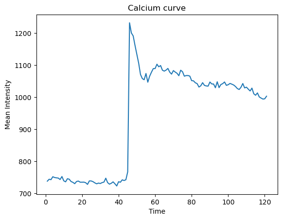

```python
import pandas as pd
import matplotlib.pyplot as plt
ID_78624=data_sorted[data_sorted['TrackID']==1000078624]
plt.plot(ID_78624['Time'], ID_78624['Intensity Mean'])
plt.xlabel('Time')
plt.ylabel('Mean Intensity')
plt.title('Calcium curve')
```

1. HW3-Q3

Calcium Curve Analysis 2

In this question, we will build upon the Calcium Curve Analysis task from Homework 2, Problem 4, where we utilized DataFrames to extract specific columns and sort rows by 'TrackID' and 'Time'. This time, we will focus on addressing the following task: Task: For each 'TrackID', verify whether the 'Time' values are consecutive. If there's a time gap, fill it with the mean of the preceding and succeeding time points. For instance, if 'Time' values are [... 5, 6, 7, 9, 10, 11, 12 ...] and corresponding 'Intensity Mean' values are [... 55, 79, 84, 63, 72, 65, 77 ...], and there's a gap at 8 in 'Time', we should insert a data point for 8 with 'Intensity Mean' as the mean of 84 and 63. This results in 'Time' becoming [... 5, 6, 7, 8, 9, 10, 11, 12 ...] and the corresponding 'Intensity Mean' becoming [... 55, 79, 84, 73.5, 63, 72, 65, 77 ...].

Output received: Size of new DataFrame with consecutive 'Time': 30581 Size of original DataFrame with non-consecutive 'Time': 28940

```python
import pandas as pd
import numpy as np

# Step i: Define a function to check if values in an array are consecutive
def check_consecutive(arr):
    return np.all(np.diff(arr) == 1)

# Step ii: Create an empty DataFrame
new_df = pd.DataFrame(columns=['Intensity Mean', 'Time', 'TrackID'])

# Step iii: Read the data from the Excel file
df = pd.read_excel('calcium_curves.xlsx', header=1)

# Step iv, v: Process each unique 'TrackID'
for track_id in df['TrackID'].unique():
    track_data = df[df['TrackID'] == track_id].sort_values(by='Time').copy()

    # Step iii: Check if 'Time' is consecutive
    if check_consecutive(track_data['Time'].values):
        # Step iv: Store tracks with consecutive 'Time' in the new DataFrame
        new_df = new_df.append(track_data, ignore_index=True)
    else:
        # Step v: Make 'Time' consecutive and fill gaps with mean values
        time_values = track_data['Time'].values
        intensity_values = track_data['Intensity Mean'].values

        missing_time_points = [time_values[i] + j for i, diff in enumerate(np.diff(time_values)) for j in range(1, diff) if diff > 1]
        interpolated_intensity_values = np.interp(missing_time_points, time_values, intensity_values)

        new_time_values = np.sort(np.concatenate([time_values, missing_time_points]))
        new_intensity_values = np.sort(np.concatenate([intensity_values, interpolated_intensity_values]))

        # Create a DataFrame for the consecutive 'Time' track
        consecutive_track_data = pd.DataFrame({
            'Intensity Mean': new_intensity_values,
            'Time': new_time_values,
            'TrackID': np.full(len(new_time_values), track_id)
        })

        # concat the consecutive track DataFrame to the new DataFrame

        new_df = pd.concat([new_df,consecutive_track_data], ignore_index=True)

# Step vi: Print the size of the new DataFrame
print("Size of new DataFrame with consecutive 'Time':", new_df.shape[0])

# Compare it with the original DataFrame size
print("Size of original DataFrame with non-consecutive 'Time':", df.shape[0])
```

[output not shown]

[output cut: 361 more lines]

[output not shown]

```
Size of new DataFrame with consecutive 'Time': 30581
Size of original DataFrame with non-consecutive 'Time': 28940
```

[output not shown]

[output cut: 16 more lines]

Output received: Size of new DataFrame with consecutive 'Time': 30581 Size of original DataFrame with non-consecutive 'Time': 28940

1. HW4-Q3

Calcium Curve Analysis 3 A. In this question, we will build upon the Calcium Curve Analysis task from Homework 2, and Homework 3, where we utilized DataFrames to extract specific columns and sort rows by 'TrackID' and 'Time' and make the DataFrame consecutive in ‘Time’. Here, we will focus on addressing the following task:

```python
import pandas as pd
import numpy as np

# Step i: Define a function to check if values in an array are consecutive
def check_consecutive(arr):
    return np.all(np.diff(arr) == 1)

# Step ii: Create an empty DataFrame
new_df = pd.DataFrame(columns=['Intensity Mean', 'Time', 'TrackID'])

# Step iii: Read the data from the Excel file
df = pd.read_excel('calcium_curves.xlsx', header=1)

# Step iv, v: Process each unique 'TrackID'
for track_id in df['TrackID'].unique():
    track_data = df[df['TrackID'] == track_id].sort_values(by='Time').copy()

    # Step iii: Check if 'Time' is consecutive
    if check_consecutive(track_data['Time'].values):
        # Step iv: Store tracks with consecutive 'Time' in the new DataFrame
        new_df = new_df.append(track_data, ignore_index=True)
    else:
        # Step v: Make 'Time' consecutive and fill gaps with mean values
        time_values = track_data['Time'].values
        intensity_values = track_data['Intensity Mean'].values

        missing_time_points = [time_values[i] + j for i, diff in enumerate(np.diff(time_values)) for j in range(1, diff) if diff > 1]
        interpolated_intensity_values = np.interp(missing_time_points, time_values, intensity_values)

        new_time_values = np.sort(np.concatenate([time_values, missing_time_points]))
        new_intensity_values = np.sort(np.concatenate([intensity_values, interpolated_intensity_values]))

        # Create a DataFrame for the consecutive 'Time' track
        consecutive_track_data = pd.DataFrame({
            'Intensity Mean': new_intensity_values,
            'Time': new_time_values,
            'TrackID': np.full(len(new_time_values), track_id)
        })

        # concat the consecutive track DataFrame to the new DataFrame

        new_df = pd.concat([new_df,consecutive_track_data], ignore_index=True)

# Step vi: Print the size of the new DataFrame
print("Size of new DataFrame with consecutive 'Time':", new_df.shape[0])

# Compare it with the original DataFrame size
print("Size of original DataFrame with non-consecutive 'Time':", df.shape[0])
```

[output not shown]

[output cut: 347 more lines]

[output not shown]

```
Size of new DataFrame with consecutive 'Time': 30581
Size of original DataFrame with non-consecutive 'Time': 28940
```

[output not shown]

[output cut: 21 more lines]

[output not shown]

[output cut: 409 more lines]

[output not shown]

```
Size of new DataFrame with consecutive 'Time': 30581
Size of original DataFrame with non-consecutive 'Time': 28940
```

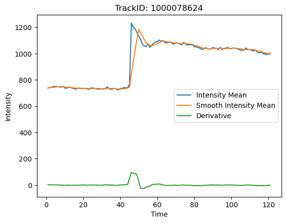

```python
import pandas as pd
import numpy as np
import matplotlib.pyplot as plt

# Smooth the 'Intensity Mean' curve by calculating the moving mean
moving_average_window_size = 5
df_full = pd.DataFrame(columns=["Intensity Mean", "Time", "TrackID", "Intensity Smooth", "Intensity Derivative"])

for ID in new_df.TrackID.unique():
    df_track = new_df[new_df["TrackID"] == ID]

    # Moving average
    moving_mean = df_track["Intensity Mean"].rolling(window=moving_average_window_size, min_periods=1).mean()

    # Derivative
    derivative = np.gradient(moving_mean)

    # Create new columns
    new_data = {
        "Intensity Mean": df_track["Intensity Mean"],
        "Time": df_track["Time"],
        "TrackID": df_track["TrackID"],
        "Intensity Smooth": moving_mean,
        "Intensity Derivative": derivative
    }

    # Concatenate new data with the existing DataFrame
    df_full = pd.concat([df_full, pd.DataFrame(new_data)])

# Plotting example for TrackID 1000078624
track_id =  1000078624
track_data = df_full[df_full["TrackID"] == track_id]

plt.plot(track_data["Time"], track_data["Intensity Mean"], label="Intensity Mean")
plt.plot(track_data["Time"], track_data["Intensity Smooth"], label="Smooth Intensity Mean")
plt.plot(track_data["Time"], track_data["Intensity Derivative"], label="Derivative")
plt.xlabel("Time")
plt.ylabel("Intensity")
plt.title(f"TrackID: {track_id}")
plt.legend()
plt.show()
```

1. Now you should have the derivatives of the ‘Intensity Mean’ for each TrackID. If there is a rapid increase in ‘Intensity Mean’, you will find a peak in the corresponding derivatives. (scipy.signal.find_peaks)

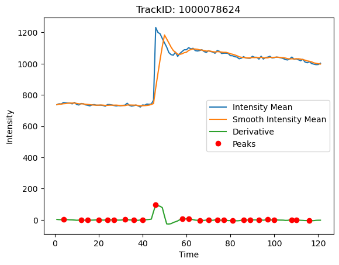

```python
import pandas as pd
import numpy as np
import matplotlib.pyplot as plt
from scipy.signal import find_peaks

# Smooth the 'Intensity Mean' curve by calculating the moving mean
moving_average_window_size = 5
df_full = pd.DataFrame(columns=["Intensity Mean", "Time", "TrackID", "Intensity Smooth", "Intensity Derivative"])

for ID in new_df.TrackID.unique():
    df_track = new_df[new_df["TrackID"] == ID]

    # Moving average
    moving_mean = df_track["Intensity Mean"].rolling(window=moving_average_window_size, min_periods=1).mean()

    # Derivative
    derivative = np.gradient(moving_mean)

    # Create new columns
    new_data = {
        "Intensity Mean": df_track["Intensity Mean"],
        "Time": df_track["Time"],
        "TrackID": df_track["TrackID"],
        "Intensity Smooth": moving_mean,
        "Intensity Derivative": derivative
    }

    # Concatenate new data with the existing DataFrame
    df_full = pd.concat([df_full, pd.DataFrame(new_data)])

# Plotting example for TrackID 1000078624
track_id = 1000078624
track_data = df_full[df_full["TrackID"] == track_id].reset_index(drop=True)

# Calculate peaks in the derivatives
peaks, _ = find_peaks(track_data["Intensity Derivative"])

# Plot the curves and peaks
plt.plot(track_data["Time"], track_data["Intensity Mean"], label="Intensity Mean")
plt.plot(track_data["Time"], track_data["Intensity Smooth"], label="Smooth Intensity Mean")
plt.plot(track_data["Time"], track_data["Intensity Derivative"], label="Derivative")
plt.plot(track_data["Time"][peaks], track_data["Intensity Derivative"][peaks], "ro", label="Peaks")
plt.xlabel("Time")
plt.ylabel("Intensity")
plt.title(f"TrackID: {track_id}")
plt.legend()
plt.show()
```

1. Define a threshold for the peak. If the height of the peak is greater than this threshold, the cell is considered activated.

Answer. For this project, I am taking the threshold to be 0.5, (that is threshold = 0.5)

1. Find the time of activation (at what time the peak happens).

```python
import pandas as pd
import numpy as np
import matplotlib.pyplot as plt
from scipy.signal import find_peaks

# Smooth the 'Intensity Mean' curve by calculating the moving mean
moving_average_window_size = 5
df_full = pd.DataFrame(columns=["Intensity Mean", "Time", "TrackID", "Intensity Smooth", "Intensity Derivative"])

for ID in new_df.TrackID.unique():
    df_track = new_df[new_df["TrackID"] == ID]

    # Moving average
    moving_mean = df_track["Intensity Mean"].rolling(window=moving_average_window_size, min_periods=1).mean()

    # Derivative
    derivative = np.gradient(moving_mean)

    # Create new columns
    new_data = {
        "Intensity Mean": df_track["Intensity Mean"],
        "Time": df_track["Time"],
        "TrackID": df_track["TrackID"],
        "Intensity Smooth": moving_mean,
        "Intensity Derivative": derivative
    }

    # Concatenate new data with the existing DataFrame
    df_full = pd.concat([df_full, pd.DataFrame(new_data)])

# Set the threshold
threshold = 0.5

# Find the activated cells based on the threshold
activated_cells = df_full[df_full["Intensity Derivative"] > threshold]

# Find the time of activation for each peak
activated_peaks, _ = find_peaks(activated_cells["Intensity Derivative"])
activation_times = activated_cells["Time"].iloc[activated_peaks]

# Display the time of activation
print("Time of Activation:")
print(activation_times)
```

```
Time of Activation:
5          6
14        15
17        18
29        30
32        33
        ...
30546    115
30560    115
30564    119
30574    115
30578    119
Name: Time, Length: 2993, dtype: object
```

1. Randomly select 50 activated cells. Plot their “Intensity Mean” as y-axis, and “Time” as x-axis together with the time of activation point in subplots of 10 rows and 5 columns.

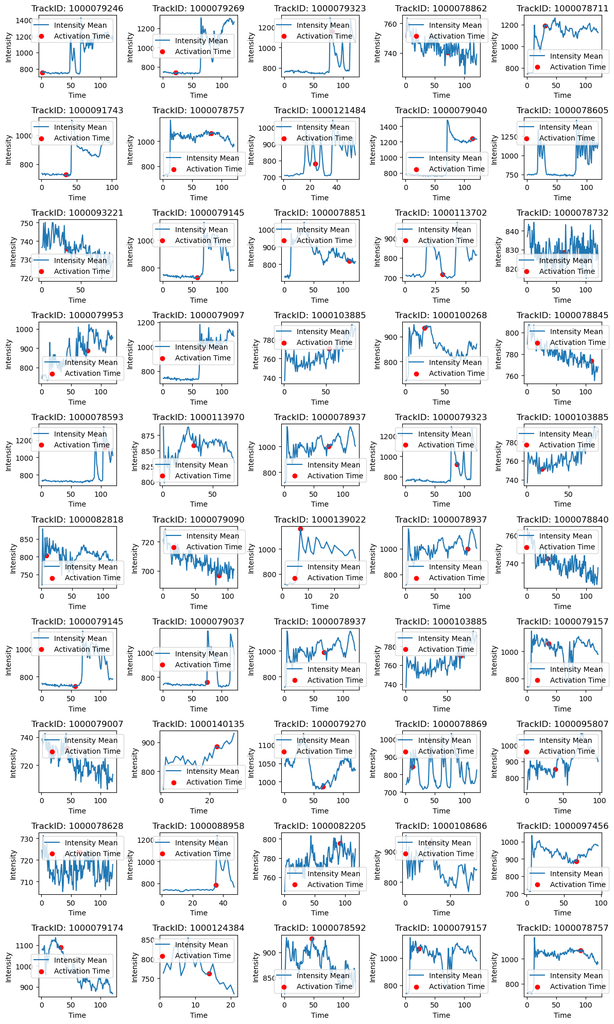

```python
import pandas as pd
import numpy as np
import matplotlib.pyplot as plt
import scipy.signal as signal

# Step iii: Read the data from the Excel file
df = pd.read_excel('calcium_curves.xlsx', header=1)

# Step 1: Select TrackID with more than 20 time points
new_df = df.groupby('TrackID').filter(lambda x: len(x) > 20).copy()
new_df['Time'] = new_df.groupby('TrackID')['Time'].rank()

# Step 2: Smooth the 'Intensity Mean' curve
windowsize = 5
new_df['smooth Intensity Mean'] = new_df['Intensity Mean'].rolling(window=windowsize, min_periods=1).mean()

# Step iii: Read the data from the Excel file
df = pd.read_excel('calcium_curves.xlsx', header=1)

# Step 3: Calculate the derivative of the smoothed 'Intensity Mean'
new_df['derivative'] = np.gradient(new_df['smooth Intensity Mean'])

# Find all activated cells with peak value greater than 0.5
threshold = 0.5
activated_cells = new_df[new_df['derivative'] > threshold]

# Randomly select 50 activated cells
random_cells = activated_cells.sample(n=50, random_state=42)

# Create subplots with 10 rows and 5 columns
fig, axs = plt.subplots(10, 5, figsize=(12, 20))

# Plot each selected cell and its activation time on a separate subplot
for i, (index, cell) in enumerate(random_cells.iterrows()):
    row = i // 5
    col = i % 5
    ax = axs[row, col]
    track_id = cell['TrackID']
    track_data = new_df[new_df['TrackID'] == track_id]
    activation_time = cell['Time']
    ax.plot(track_data['Time'], track_data['Intensity Mean'], label='Intensity Mean')
    ax.scatter(activation_time, cell['Intensity Mean'], color='red', label='Activation Time')
    ax.set_xlabel('Time')
    ax.set_ylabel('Intensity')
    ax.set_title(f'TrackID: {track_id}')
    ax.legend()

# Adjust the spacing between the subplots
plt.tight_layout()
plt.show()
```

1. Randomly select 50 unactivated cells. Plot their “Intensity Mean” as y-axis, and “Time” as in subplots of 10 rows and 5 columns

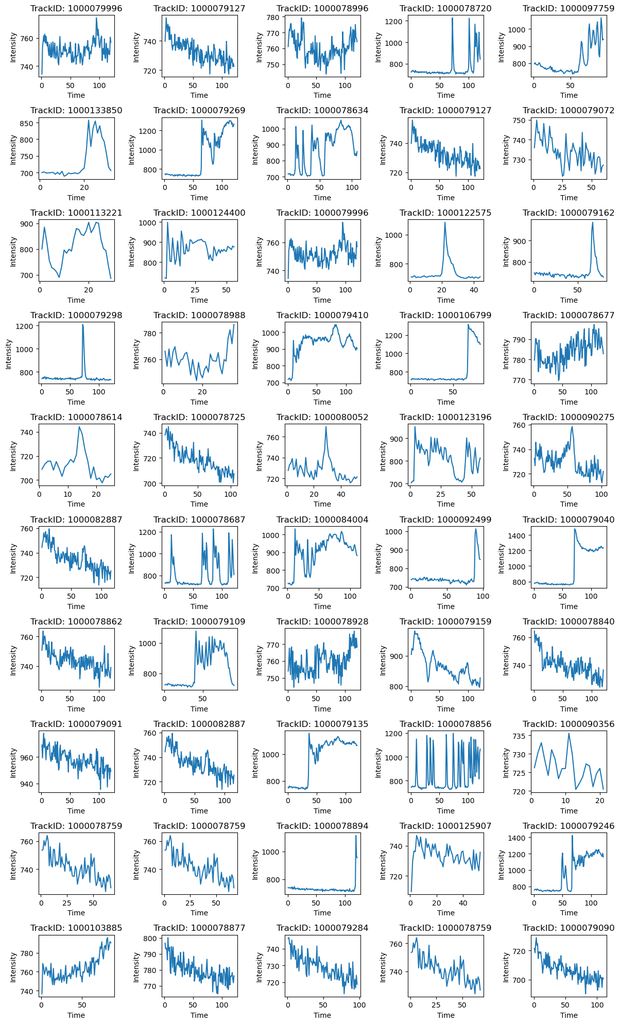

```python
import pandas as pd
import numpy as np
import matplotlib.pyplot as plt
import scipy.signal as signal

# Step iii: Read the data from the Excel file
df = pd.read_excel('calcium_curves.xlsx', header=1)

# Step 1: Select TrackID with more than 20 time points
new_df = df.groupby('TrackID').filter(lambda x: len(x) > 20).copy()
new_df['Time'] = new_df.groupby('TrackID')['Time'].rank()

# Step 2: Smooth the 'Intensity Mean' curve
windowsize = 5
new_df['smooth Intensity Mean'] = new_df['Intensity Mean'].rolling(window=windowsize, min_periods=1).mean()

# Step 3: Calculate the derivative of the smoothed 'Intensity Mean'
new_df['derivative'] = np.gradient(new_df['smooth Intensity Mean'])

# Step ii: Filter unactivated cells
threshold = 0.5
unactivated_cells = new_df[new_df['derivative'] <= threshold]

# Randomly select 50 unactivated cells
random_cells = unactivated_cells.sample(n=50, random_state=42)

# Create subplots with 10 rows and 5 columns
fig, axs = plt.subplots(10, 5, figsize=(12, 20))

# Plot each selected unactivated cell on a separate subplot
for i, (index, cell) in enumerate(random_cells.iterrows()):
    row = i // 5
    col = i % 5
    ax = axs[row, col]
    track_id = cell['TrackID']
    track_data = new_df[new_df['TrackID'] == track_id]
    ax.plot(track_data['Time'], track_data['Intensity Mean'])
    ax.set_xlabel('Time')
    ax.set_ylabel('Intensity')
    ax.set_title(f'TrackID: {track_id}')

# Adjust the spacing between the subplots
plt.tight_layout()
plt.show()
```

1. Visually check if your threshold works well in separating activated vs unactivated curves. If not, adjust the threshold.

1. Find all activated cells and save the corresponding ‘Intensity Mean’, ‘Time’ and ‘TrackID’ to a new DataFrame.

```python
import pandas as pd
import numpy as np
import matplotlib.pyplot as plt
from scipy.signal import find_peaks

# Smooth the 'Intensity Mean' curve by calculating the moving mean
moving_average_window_size = 5
df_full = pd.DataFrame(columns=["Intensity Mean", "Time", "TrackID", "Intensity Smooth", "Intensity Derivative"])

for ID in new_df.TrackID.unique():
    df_track = new_df[new_df["TrackID"] == ID]

    # Moving average
    moving_mean = df_track["Intensity Mean"].rolling(window=moving_average_window_size, min_periods=1).mean()

    # Derivative
    derivative = np.gradient(moving_mean)

    # Create new columns
    new_data = {
        "Intensity Mean": df_track["Intensity Mean"],
        "Time": df_track["Time"],
        "TrackID": df_track["TrackID"],
        "Intensity Smooth": moving_mean,
        "Intensity Derivative": derivative
    }

    # Concatenate new data with the existing DataFrame
    df_full = pd.concat([df_full, pd.DataFrame(new_data)])

# Set the threshold
threshold = 0.5

#  the activated cells based on the threshold
activated_cells = df_full[df_full["Intensity Derivative"] > threshold].copy()

# Save the 'Intensity Mean', 'Time', and 'TrackID' to a new DataFrame
activated_cells_subset = activated_cells[["Intensity Mean", "Time", "TrackID"]].reset_index(drop=True)

# Display the activated cells data
print("Activated Cells Data:")
print(activated_cells_subset)
```

```
Activated Cells Data:
      Intensity Mean  Time     TrackID
0         817.684021   1.0  1000078592
1         866.911987   2.0  1000078592
2         907.570007   3.0  1000078592
3         929.346985   4.0  1000078592
4         912.531982   5.0  1000078592
...              ...   ...         ...
9968     1039.380005   8.0  1000145701
9969      917.400024  15.0  1000145701
9970      961.885010  16.0  1000145701
9971      956.526001  19.0  1000145701
9972      966.359009  20.0  1000145701

[9973 rows x 3 columns]
```

1. Find all unactivated cells and save the corresponding ‘Intensity Mean’, ‘Time’ and ‘TrackID’ to a new DataFrame.

```python
import pandas as pd
import numpy as np
import matplotlib.pyplot as plt
from scipy.signal import find_peaks

# Smooth the 'Intensity Mean' curve by calculating the moving mean
moving_average_window_size = 5
df_full = pd.DataFrame(columns=["Intensity Mean", "Time", "TrackID", "Intensity Smooth", "Intensity Derivative"])

for ID in new_df.TrackID.unique():
    df_track = new_df[new_df["TrackID"] == ID]

    # Moving average
    moving_mean = df_track["Intensity Mean"].rolling(window=moving_average_window_size, min_periods=1).mean()

    # Derivative
    derivative = np.gradient(moving_mean)

    # Create new columns
    new_data = {
        "Intensity Mean": df_track["Intensity Mean"],
        "Time": df_track["Time"],
        "TrackID": df_track["TrackID"],
        "Intensity Smooth": moving_mean,
        "Intensity Derivative": derivative
    }

    # Concatenate new data with the existing DataFrame
    df_full = pd.concat([df_full, pd.DataFrame(new_data)])

# Set the threshold
threshold = 0.5

#  the unactivated cells based on the threshold
unactivated_cells = df_full[df_full["Intensity Derivative"] <= threshold].copy()

# Save the 'Intensity Mean', 'Time', and 'TrackID' to a new DataFrame
unactivated_cells_subset = unactivated_cells[["Intensity Mean", "Time", "TrackID"]].reset_index(drop=True)

# Display the unactivated cells data
print("Unactivated Cells Data:")
print(unactivated_cells_subset)
```

```
Unactivated Cells Data:
       Intensity Mean  Time     TrackID
0          909.299988   8.0  1000078592
1          905.577026   9.0  1000078592
2          893.518982  10.0  1000078592
3          882.594971  11.0  1000078592
4          884.341980  12.0  1000078592
...               ...   ...         ...
16903     1028.280029  13.0  1000145701
16904      986.213013  14.0  1000145701
16905      917.013000  17.0  1000145701
16906      941.820007  18.0  1000145701
16907      941.921021  21.0  1000145701

[16908 rows x 3 columns]
```

1. What is the percentage of activated cells?

```python
import pandas as pd
import numpy as np
import matplotlib.pyplot as plt
from scipy.signal import find_peaks

# Smooth the 'Intensity Mean' curve by calculating the moving mean
moving_average_window_size = 5
df_full = pd.DataFrame(columns=["Intensity Mean", "Time", "TrackID", "Intensity Smooth", "Intensity Derivative"])

for ID in new_df.TrackID.unique():
    df_track = new_df[new_df["TrackID"] == ID]

    # Moving average
    moving_mean = df_track["Intensity Mean"].rolling(window=moving_average_window_size, min_periods=1).mean()

    # Derivative
    derivative = np.gradient(moving_mean)

    # Create new columns
    new_data = {
        "Intensity Mean": df_track["Intensity Mean"],
        "Time": df_track["Time"],
        "TrackID": df_track["TrackID"],
        "Intensity Smooth": moving_mean,
        "Intensity Derivative": derivative
    }

    # Concatenate new data with the existing DataFrame
    df_full = pd.concat([df_full, pd.DataFrame(new_data)])

# Set the threshold
threshold = 0.5

# the activated cells based on the threshold
activated_cells = df_full[df_full["Intensity Derivative"] > threshold]

# Calculate the number of activated cells and total number of cells
num_activated_cells = len(activated_cells)
total_cells = len(df_full)

# Calculate the percentage of activated cells
percentage_activated_cells = (num_activated_cells / total_cells) * 100

# Display the percentage of activated cells
print("Percentage of Activated Cells:", percentage_activated_cells)
```

```
Percentage of Activated Cells: 37.1005542948551
```

1. For all activated cells, set the starting of Time to 1. For example:‘TrackID’: 100001, ‘Intensity Mean’:[1.1, 2.2, 3.3, .... 9.9, 10.10],‘Time’: [11, 12, 13, .....,19, 20] -> ‘Time’: [1, 2, 3, .....,9, 10]

```python
import pandas as pd
import numpy as np
import matplotlib.pyplot as plt
from scipy.signal import find_peaks

# Smooth the 'Intensity Mean' curve by calculating the moving mean
moving_average_window_size = 5
df_full = pd.DataFrame(
    columns=[
        "Intensity Mean",
        "Time",
        "TrackID",
        "Intensity Smooth",
        "Intensity Derivative",
    ]
)

for ID in new_df.TrackID.unique():
    df_track = new_df[new_df["TrackID"] == ID]

    # Moving average
    moving_mean = df_track["Intensity Mean"].rolling(
        window=moving_average_window_size, min_periods=1
    ).mean()

    # Derivative
    derivative = np.gradient(moving_mean)

    # Create new columns
    new_data = {
        "Intensity Mean": df_track["Intensity Mean"],
        "Time": df_track["Time"],
        "TrackID": df_track["TrackID"],
        "Intensity Smooth": moving_mean,
        "Intensity Derivative": derivative,
    }

    # Concatenate new data with the existing DataFrame
    df_full = pd.concat([df_full, pd.DataFrame(new_data)])

# Set the threshold
threshold = 0.5

# the activated cells based on the threshold
activated_cells = df_full[df_full["Intensity Derivative"] > threshold].copy()

# Set the starting time to 1 for activated cells
activated_cells["Time"] = activated_cells.groupby("TrackID")["Time"].transform(
    lambda x: x - x.min() + 1
)

# Display the modified activated cells data
print("Modified Activated Cells Data:")
print(activated_cells)
```

```
Modified Activated Cells Data:
       Intensity Mean  Time     TrackID  Intensity Smooth  \
0          817.684021   1.0  1000078592        817.684021
183        866.911987   2.0  1000078592        842.298004
371        907.570007   3.0  1000078592        864.055339
557        929.346985   4.0  1000078592        880.378250
744        912.531982   5.0  1000078592        886.808997
...               ...   ...         ...               ...
25404     1039.380005   8.0  1000145701       1018.957996
27321      917.400024  15.0  1000145701        938.723413
27591      961.885010  16.0  1000145701        958.710620
28399      956.526001  19.0  1000145701        938.928809
28663      966.359009  20.0  1000145701        948.720605

       Intensity Derivative
0                 24.613983
183               23.185659
371               19.040123
557               11.376829
744               12.439268
...                     ...
25404             14.018201
27321              8.157605
27591             11.717401
28399              1.927197
28663              2.899500

[9973 rows x 5 columns]
```

1. Calculate the average and SEM starting from the beginning of the track (Time=1).

```python
import pandas as pd
import numpy as np
import matplotlib.pyplot as plt
from scipy.signal import find_peaks

# Smooth the 'Intensity Mean' curve by calculating the moving mean
moving_average_window_size = 5
df_full = pd.DataFrame(
    columns=[
        "Intensity Mean",
        "Time",
        "TrackID",
        "Intensity Smooth",
        "Intensity Derivative",
    ]
)

for ID in new_df.TrackID.unique():
    df_track = new_df[new_df["TrackID"] == ID]

    # Moving average
    moving_mean = df_track["Intensity Mean"].rolling(
        window=moving_average_window_size, min_periods=1
    ).mean()

    # Derivative
    derivative = np.gradient(moving_mean)

    # Create new columns
    new_data = {
        "Intensity Mean": df_track["Intensity Mean"],
        "Time": df_track["Time"],
        "TrackID": df_track["TrackID"],
        "Intensity Smooth": moving_mean,
        "Intensity Derivative": derivative,
    }

    # Concatenate new data with the existing DataFrame
    df_full = pd.concat([df_full, pd.DataFrame(new_data)])

# Set the threshold
threshold = 0.5

# Find the activated cells based on the threshold
activated_cells = df_full[df_full["Intensity Derivative"] > threshold].copy()

# Set the starting time to 1 for activated cells
activated_cells["Time"] = activated_cells.groupby("TrackID")["Time"].transform(
    lambda x: x - x.min() + 1
)

# Calculate the average and SEM starting from Time = 1
average_intensity = activated_cells.groupby("Time")["Intensity Mean"].mean()
sem_intensity = activated_cells.groupby("Time")["Intensity Mean"].sem()

# Display the average and SEM
print("Average Intensity starting from Time=1:")
print(average_intensity)
print("\nSEM (Standard Error of the Mean) starting from Time=1:")
print(sem_intensity)
```

```
Average Intensity starting from Time=1:
Time
1.0       759.095176
2.0       793.213019
3.0       824.180263
4.0       827.084172
5.0       821.895781
            ...
117.0    1048.817512
118.0    1027.085425
119.0     998.071348
120.0     956.352108
121.0    1079.254211
Name: Intensity Mean, Length: 121, dtype: float64

SEM (Standard Error of the Mean) starting from Time=1:
Time
1.0        6.205552
2.0        8.797946
3.0       12.003022
4.0       12.114020
5.0        9.945276
            ...
117.0     54.587918
118.0     54.004907
119.0     41.473950
120.0     76.546357
121.0    125.452625
Name: Intensity Mean, Length: 121, dtype: float64
```

1. Plot the average calcium curve for all activated cells with SEM as error bars.

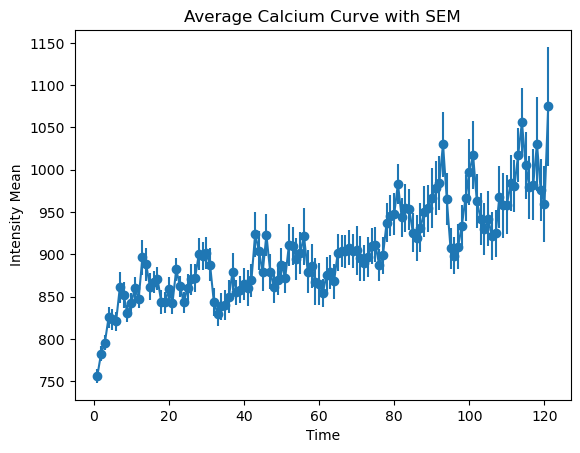

```python
import pandas as pd
import numpy as np
import matplotlib.pyplot as plt
from scipy.signal import find_peaks

# Smooth the 'Intensity Mean' curve by calculating the moving mean
moving_average_window_size = 5
df_full = pd.DataFrame(columns=["Intensity Mean", "Time", "TrackID", "Intensity Smooth", "Intensity Derivative"])

for ID in new_df.TrackID.unique():
    df_track = new_df[new_df["TrackID"] == ID]

    # Moving average
    moving_mean = df_track["Intensity Mean"].rolling(window=moving_average_window_size, min_periods=1).mean()

    # Derivative
    derivative = np.gradient(moving_mean)

    # Create new columns
    new_data = {
        "Intensity Mean": df_track["Intensity Mean"],
        "Time": df_track["Time"],
        "TrackID": df_track["TrackID"],
        "Intensity Smooth": moving_mean,
        "Intensity Derivative": derivative
    }

    # Concatenate new data with the existing DataFrame
    df_full = pd.concat([df_full, pd.DataFrame(new_data)])

# Set the threshold
threshold = 0.5

# Find the activated cells based on the threshold
activated_cells = df_full[df_full["Intensity Derivative"] > threshold].copy()

# Calculate the average calcium curve and SEM
average_curve = activated_cells.groupby("Time")["Intensity Mean"].mean()
sem_curve = activated_cells.groupby("Time")["Intensity Mean"].sem()

# Plot the average calcium curve with SEM as error bars
plt.errorbar(average_curve.index, average_curve.values, yerr=sem_curve.values, fmt="-o")

# Set the plot title and labels
plt.title("Average Calcium Curve with SEM")
plt.xlabel("Time")
plt.ylabel("Intensity Mean")

# Show the plot
plt.show()
```

1. Bonus Question:
2. Calculate the average and SEM starting from the beginning of the activation.

```python
import pandas as pd
import numpy as np
import matplotlib.pyplot as plt
from scipy.signal import find_peaks

# Smooth the 'Intensity Mean' curve by calculating the moving mean
moving_average_window_size = 5
df_full = pd.DataFrame(columns=["Intensity Mean", "Time", "TrackID", "Intensity Smooth", "Intensity Derivative"])

for ID in new_df.TrackID.unique():
    df_track = new_df[new_df["TrackID"] == ID]

    # Moving average
    moving_mean = df_track["Intensity Mean"].rolling(window=moving_average_window_size, min_periods=1).mean()

    # Derivative
    derivative = np.gradient(moving_mean)

    # Create new columns
    new_data = {
        "Intensity Mean": df_track["Intensity Mean"],
        "Time": df_track["Time"],
        "TrackID": df_track["TrackID"],
        "Intensity Smooth": moving_mean,
        "Intensity Derivative": derivative
    }

    # Concatenate new data with the existing DataFrame
    df_full = pd.concat([df_full, pd.DataFrame(new_data)])

# Set the threshold
threshold = 0.5

# Find the activated cells based on the threshold
activated_cells = df_full[df_full["Intensity Derivative"] > threshold]

# Find the time of activation for each activated cell
activation_times = activated_cells.groupby("TrackID")["Time"].transform("min")

# Calculate the time relative to the beginning of activation
time_since_activation = activated_cells["Time"] - activation_times + 1

# Calculate the average and SEM starting from the beginning of the activation
average_intensity = activated_cells.groupby(time_since_activation)["Intensity Mean"].mean()
sem_intensity = activated_cells.groupby(time_since_activation)["Intensity Mean"].sem()

# Display the average and SEM
print("Average Intensity starting from the beginning of activation:")
print(average_intensity)
print("\nSEM (Standard Error of the Mean) starting from the beginning of activation:")
print(sem_intensity)
```

```
Average Intensity starting from the beginning of activation:
Time
1.0       759.095176
2.0       793.213019
3.0       824.180263
4.0       827.084172
5.0       821.895781
            ...
117.0    1048.817512
118.0    1027.085425
119.0     998.071348
120.0     956.352108
121.0    1079.254211
Name: Intensity Mean, Length: 121, dtype: float64

SEM (Standard Error of the Mean) starting from the beginning of activation:
Time
1.0        6.205552
2.0        8.797946
3.0       12.003022
4.0       12.114020
5.0        9.945276
            ...
117.0     54.587918
118.0     54.004907
119.0     41.473950
120.0     76.546357
121.0    125.452625
Name: Intensity Mean, Length: 121, dtype: float64
```

1. Plot the average calcium curve for all activated cells with SEM as error bars.

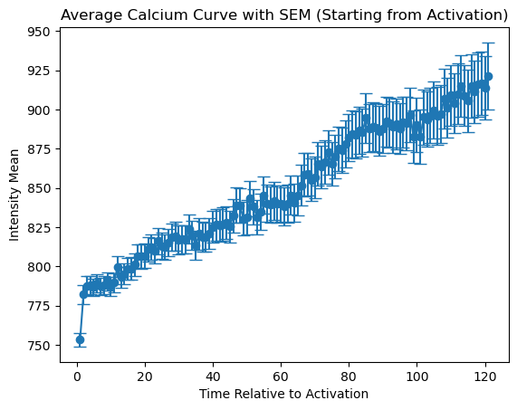

```python
import pandas as pd
import numpy as np
import matplotlib.pyplot as plt
from scipy import stats

# Step i: Read the data from the Excel file
df = pd.read_excel('calcium_curves.xlsx', header=1)

# Step ii: Filter activated cells
threshold = 0.5
activated_cells = df[df['Intensity Mean'] > threshold]

# Calculate the starting time for each activation
activation_start_times = activated_cells.groupby('TrackID')['Time'].transform('min')

# Calculate the time relative to the beginning of activation
activated_cells['Time Relative to Activation'] = activated_cells['Time'] - activation_start_times + 1

# Calculate the average and SEM starting from the beginning of the activation
average = activated_cells.groupby('Time Relative to Activation')['Intensity Mean'].mean()
sem = activated_cells.groupby('Time Relative to Activation')['Intensity Mean'].sem()

# Plot the average calcium curve with SEM as error bars
plt.errorbar(average.index, average.values, yerr=sem, fmt='o-', capsize=5)
plt.xlabel('Time Relative to Activation')
plt.ylabel('Intensity Mean')
plt.title('Average Calcium Curve with SEM (Starting from Activation)')
plt.show()
```